# [CSE426] Image Processing

Teaching Assistant: Hyunmin Ban (hmban1996@khu.ac.kr)

Professor: Hui Yong Kim (hykim.v@khu.ac.kr)

# P2: Intensity Transformation

## P2.A: Gamma Transformation (4점)

### 실습내용

실습은 다음 순서로 진행됩니다.

- 0) 실습에서 사용되는 패키지 import
- 1) 주어진 이미지 loading
- 2) 함수 정의 **(code 구현)**
- 3) Matplotlib로 이미지 확인

### 점수

- 2) 함수 구현 4점

### 제출방법

- .ipynb 파일과 함께 .html 파일 (File -> export (Download) as -> HTML)도 함께 제출하세요. 하나만 제출할시 감점이 있습니다.
- e-campus에 .ipynb 파일과 .html 파일을 zip파일로 하지 말고 따로따로 올리세요.

## Imports

```python
import cv2
import numpy as np
import matplotlib.pyplot as plt
import matplotlib.image as img
```

## 1) Load Image

```python
img = cv2.imread('aerial.jpg', cv2.IMREAD_GRAYSCALE) # 이미지 파일 읽기

cv2.imshow('image', img)
cv2.waitKey(0)
cv2.destroyAllWindows()
```

## 2) Define Function

**요구사항**

- power-law transform을 직접 구현하세요

```python
def power_law(gamma, img):

    c = 255 / (img.max() ** gamma)
    result = (c * (img ** gamma)).astype(np.uint8)

    return result
```

## 3) Plot Image

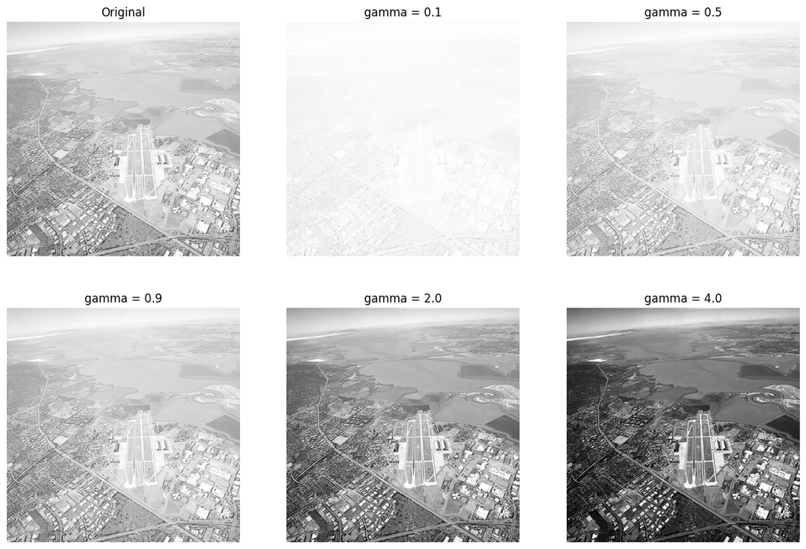

```python
fig = plt.figure(figsize = (15, 10)) # rows*cols 행렬의 i번째 subplot 생성
rows = 2
cols = 3

ax1 = fig.add_subplot(rows, cols, 1)
image = cv2.cvtColor(img, cv2.COLOR_GRAY2RGB) # matplot 라이브러리의 imshow함수를 사용하여 영상을 보일경우, RGB 포맷으로 변환해주어야 함
ax1.imshow(image)
ax1.set_title('Original')
ax1.axis("off")

ax2 = fig.add_subplot(rows, cols, 2)
gamma0 = cv2.cvtColor(power_law(0.1, img), cv2.COLOR_GRAY2RGB)
ax2.imshow(gamma0)
ax2.set_title('gamma = 0.1')
ax2.axis("off")

ax3 = fig.add_subplot(rows, cols, 3)
gamma1 = cv2.cvtColor(power_law(0.5, img), cv2.COLOR_GRAY2RGB)
ax3.imshow(gamma1)
ax3.set_title('gamma = 0.5')
ax3.axis("off")

ax4 = fig.add_subplot(rows, cols, 4)
gamma2 = cv2.cvtColor(power_law(0.9, img), cv2.COLOR_GRAY2RGB)
ax4.imshow(gamma2)
ax4.set_title('gamma = 0.9')
ax4.axis("off")

ax5 = fig.add_subplot(rows, cols, 5)
gamma3 = cv2.cvtColor(power_law(2.0, img), cv2.COLOR_GRAY2RGB)
ax5.imshow(gamma3)
ax5.set_title('gamma = 2.0')
ax5.axis("off")

ax6 = fig.add_subplot(rows, cols, 6)
gamma4 = cv2.cvtColor(power_law(4.0, img), cv2.COLOR_GRAY2RGB)
ax6.imshow(gamma4)
ax6.set_title('gamma = 4.0')
ax6.axis("off")

plt.show()
```

## P2.B: Histogram Processing (6점)

### 실습내용

실습은 다음 순서로 진행됩니다.

- 1) 이미지 loading
- 2) 함수 정의 **(code 구현)**
- 3) Matplotlib로 이미지 확인
- 4) Discussion

### 점수

- 2) 함수 구현 6점
- Discussion 작성에 불성실하면 감점

### 제출방법

- .ipynb 파일과 함께 .html 파일 (File -> export (Download) as -> HTML)도 함께 제출하세요. 하나만 제출할시 감점이 있습니다.

## 1) Load Image

```python
img = cv2.imread('pollen.jpg', cv2.IMREAD_GRAYSCALE)
cv2.imshow('image', img)
cv2.waitKey(0)
cv2.destroyAllWindows()
```

## 2) Define Function

**요구사항**

- 1) Histogram Stretching을 직접 구현하세요
- 2) Histogram Equalization을 opencv의 equalizeHist를 사용하지 마시고 직접 구현하세요
- 3) Histogram 함수는 numpy 혹은 opencv 함수를 사용하면 됩니다.

```python
def Hist_Stretch(img):

    min_val = img.min()
    max_val = img.max()
    result = ((img - min_val) * (255.0 / (max_val - min_val))).astype(np.uint8)

    return result


my_HS = Hist_Stretch(img)
```

```python
def Hist_Equalization(img):

    hist, bins = np.histogram(img.flatten(), 256, [0,256])
    cdf = hist.cumsum()
    cdf_normalized = cdf * hist.max() / cdf.max()

    result = np.interp(img.flatten(), bins[:-1], cdf_normalized).reshape(img.shape)
    result = result.astype(np.uint8)

    return result

my_HE = Hist_Equalization(img)
```

```python
# opencv로 Histogram Equalization을 한 것으로 직접 구현한 함수와 비교하기 위해 사용
cv2_HE = cv2.equalizeHist(cv2.imread('pollen.jpg', cv2.IMREAD_GRAYSCALE))
```

## 3) Plot Image

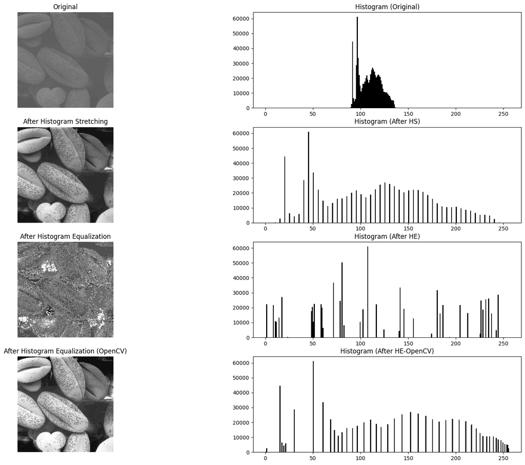

```python
fig = plt.figure(figsize = (20, 15)) # rows*cols 행렬의 i번째 subplot 생성
rows = 4
cols = 2

ax1 = fig.add_subplot(rows, cols, 1)
image = cv2.cvtColor(img, cv2.COLOR_GRAY2RGB) # matplot 라이브러리의 imshow함수를 사용하여 영상을 보일경우, RGB 포맷으로 변환해주어야 함
ax1.imshow(image)
ax1.set_title('Original')
ax1.axis("off")

ax2 = fig.add_subplot(rows, cols, 2)
ax2.hist(img.flatten(),256,[0,256], color = 'black')
ax2.set_title('Histogram (Original)')

ax3 = fig.add_subplot(rows, cols, 3)
ax3.imshow(cv2.cvtColor(my_HS, cv2.COLOR_GRAY2RGB))
ax3.set_title('After Histogram Stretching')
ax3.axis("off")

ax4 = fig.add_subplot(rows, cols, 4)
ax4.hist(my_HS.flatten(),256,[0,256], color = 'black')
ax4.set_title('Histogram (After HS)')

ax5 = fig.add_subplot(rows, cols, 5)
ax5.imshow(cv2.cvtColor(my_HE, cv2.COLOR_GRAY2RGB))
ax5.set_title('After Histogram Equalization')
ax5.axis("off")

ax6 = fig.add_subplot(rows, cols, 6)
ax6.hist(my_HE.flatten(),256,[0,256], color = 'black')
ax6.set_title('Histogram (After HE)')

ax7 = fig.add_subplot(rows, cols, 7)
ax7.imshow(cv2.cvtColor(cv2_HE, cv2.COLOR_GRAY2RGB), cmap='gray')
ax7.set_title('After Histogram Equalization (OpenCV)')
ax7.axis("off")

ax8 = fig.add_subplot(rows, cols, 8)
ax8.hist(cv2_HE.flatten(),256,[0,256], color = 'black')
ax8.set_title('Histogram (After HE-OpenCV)')
```

## 4) Discussion

**1) Histogram Equalization에 대해 설명하세요.**

histogram equalization를 사용하면 이미지의 대비와 밝기가 개선된다.

histogram equalization의 원리는 이미지의 히스토그램을 계산하여 누적 분포 함수를 만들고, 히스토그램이 가능한 균일하게 분포되도록 원래 픽셀 값을 새 값으로 매핑한다. 위의 과정을 통해 이미지의 빈도를 균일하게 만들어, 보다 선명한 이미지를 얻을 수 있다.

**2) Histogram Matching에 대해 설명하세요.**

histogram matching은 입력 이미지의 히스토그램과 원하는 히스토그램을 일치하도록 수정하기 위해 사용한다. 히스토그램 매칭을 통해 다른 조명 조건에서도 밝기와 대비가 유사하게 보이도록 만들 수 있다.

histogram matching의 원리는 누적 분포 함수를 통해 입력 받은 이미지의 누적 분포 함수를 변환한다. 위 과정을 진행한 뒤, 입력 이미지의 히스토그램을 원하는 히스토그램과 일치하도록 입력 이미지의 강도를 새값으로 매핑한다. 위 과정을 통해, 이미지의 품질을 상향시키거나 원하는 용도로 변환할 수 있다.

**3) 주어진 pollen.jpg 이외의 다른 사진(각자 원하는 사진)을 Histogram Equalization에 사용해보세요.**

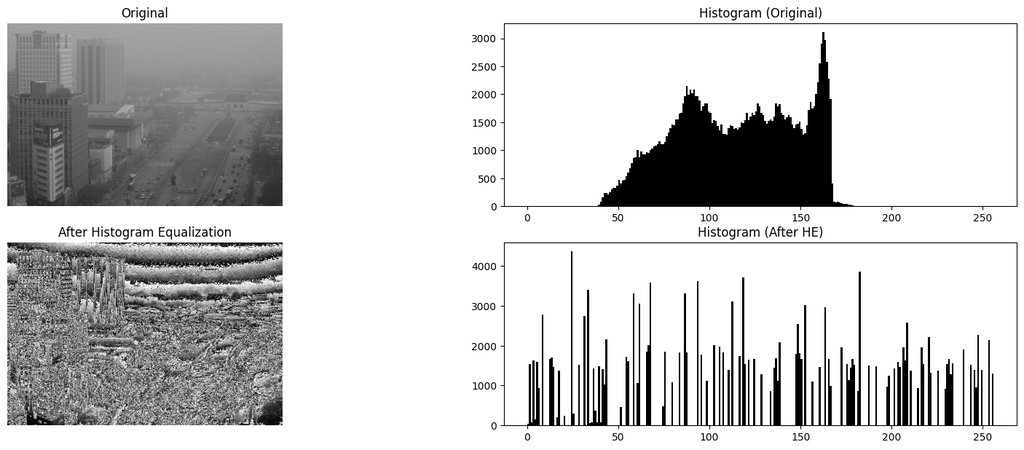

```python
my_img = cv2.imread('my_img.jpg', cv2.IMREAD_GRAYSCALE) # 이미지 파일 읽기

Hist_img = Hist_Equalization(my_img)

fig = plt.figure(figsize = (20, 15)) # rows*cols 행렬의 i번째 subplot 생성
rows = 4
cols = 2

ax1 = fig.add_subplot(rows, cols, 1)
image = cv2.cvtColor(my_img, cv2.COLOR_GRAY2RGB) # matplot 라이브러리의 imshow함수를 사용하여 영상을 보일경우, RGB 포맷으로 변환해주어야 함
ax1.imshow(image)
ax1.set_title('Original')
ax1.axis("off")

ax2 = fig.add_subplot(rows, cols, 2)
ax2.hist(my_img.flatten(),256,[0,256], color = 'black')
ax2.set_title('Histogram (Original)')

ax3 = fig.add_subplot(rows, cols, 3)
ax3.imshow(cv2.cvtColor(Hist_img, cv2.COLOR_GRAY2RGB))
ax3.set_title('After Histogram Equalization')
ax3.axis("off")

ax4 = fig.add_subplot(rows, cols, 4)
ax4.hist(Hist_img.flatten(),256,[0,256], color = 'black')
ax4.set_title('Histogram (After HE)')
```

다음 활동을 통해 무조건적으로 Histogram Equalization을 사용하는 것은 좋지 않다는 생각이 들었다.